# Classification Project

### Problem Statement

##### Hypothesis

Null hypothesis:

The model is significantly able to classify a customer as an individual who is likely to purchase a healthy product.

Alternative hypothesis:

The model is significantly unable to classify a customer as an individual who is likely to purchase a healthy product.

The significant level will be when the r coefficient is higher than 0.5 or lower than -0.5 and the p-value lower than 0.05.

### Overview

The initial plan for the project is as follows:

1. Source the data
2. Explore & clean the data
3. Prepare the data for analysis
4. Analyse the data
5. Evaluate the model
6. Improve the model

### Source the data

The data was sourced from two sources. The first source was from our enterprise analytics hub where customer transactional data was collected. Unfortunately, I was not able to connect directly to EAH, so I forced to write a SQL statement is Impala and to export the dataset in a CSV. The second source was the Health attribute data set which is a small data set that was manually maintained in excel.

Potential issues with the data, as transactional data can be quite huge, I decided for practicality that I will only export one months’ worth of data. I personally believe this may not be enough data for the model to use to be able to make a good prediction. The second issue is that the health attribute data has not been maintained since March 2019. The potential issue only a small fraction of those products may still be in our catalogue affecting the true frequency of the current amount of health products being purchased.

In terms of sharing issues, we must be very careful when dealing with customer data as this is considered private and sensitive data even though no personal data is present such as names or addresses. We also need to consider how we communicate and present the data when dealing with gender and age as these are also sensitive topics as we do not wish to present ourselves as misusing customer data.

### Explore & clean the data

Initially the idea was to explore, clean and then prepare the data but due to issue while exploring It was decided to merge the exploring and the cleaning process into one.

```python
# Import necessary packages for data exploration and analysis
import pandas as pd
import numpy as np
import matplotlib.pyplot as plt
import seaborn as sns
from sklearn import tree, metrics
from sklearn.model_selection import train_test_split
from sklearn.ensemble import RandomForestClassifier
import numpy as np
from sklearn.preprocessing import StandardScaler
import researchpy as rp
```

```python
# Load the data from a csv file into a data frame
d = pd.read_csv(r"C:\Users\c2345091\Documents\Projects\Classification\query-impala-908636.csv",encoding='cp1252')
d.head()
```

```
C:\Program Files\Anaconda3\lib\site-packages\IPython\core\interactiveshell.py:3049: DtypeWarning: Columns (67) have mixed types. Specify dtype option on import or set low_memory=False.
  interactivity=interactivity, compiler=compiler, result=result)
```

|  | event_date | purchase_channel | cust_id | cust_age | cust_gender | week_id | week_ending_date | event_datetime | basket_id | payment_type | ... | l5_id | l6_id | prev_basket_id | area_name | location_type | l1_split | sales_tax_amt | year | month | day |
| --- | --- | --- | --- | --- | --- | --- | --- | --- | --- | --- | --- | --- | --- | --- | --- | --- | --- | --- | --- | --- | --- |
| 0 | 22/10/2019 00:00 | POS | -5.777280e+18 | 70.0 | F | 201943 | 26/10/2019 00:00 | 22/10/2019 18:17 | 467165-4417-117-20191022181607 | MS Credit Card | ... | F611071 | F619175 | NaN | SCOTLAND WEST | 16 | FD | 0.00 | 2019 | 10 | 22 |
| 1 | 22/10/2019 00:00 | POS | NaN | NaN | NaN | 201943 | 26/10/2019 00:00 | 22/10/2019 11:12 | 148289-1940-100-20191022111146 | Cash | ... | F08593 | F082333 | NaN | SCOTLAND WEST | 28 | FD | 0.00 | 2019 | 10 | 22 |
| 2 | 22/10/2019 00:00 | POS | 1.942560e+18 | 70.0 | F | 201943 | 26/10/2019 00:00 | 22/10/2019 11:06 | 391417-2202-110-20191022110546 | Debit Card | ... | F064045 | F065347 | NaN | HOME COUNTIES SOUTH | 16 | FD | 0.00 | 2019 | 10 | 22 |
| 3 | 22/10/2019 00:00 | POS | NaN | NaN | NaN | 201943 | 26/10/2019 00:00 | 22/10/2019 15:36 | 94056-5295-103-20191022153544 | Cash | ... | F98151 | F982787 | NaN | SOUTH WEST | 28 | FD | 0.00 | 2019 | 10 | 22 |
| 4 | 22/10/2019 00:00 | POS | -1.968720e+18 | NaN | NaN | 201943 | 26/10/2019 00:00 | 22/10/2019 20:07 | 300517-1290-101-20191022200617 | Debit Card | ... | T60603 | T6063E | NaN | CENTRAL LONDON | 16 | CL | 1.33 | 2019 | 10 | 22 |

5 rows × 75 columns

```python
# Gather basic information about the dataset
print(f"Rows: {d.shape[0]}\nColumns: {d.shape[1]}")
```

```
Rows: 99999
Columns: 75
```

```python
# Show the time period of the data
print (d.event_date.min())
print (d.event_date.max())
```

```
01/10/2019 00:00
30/10/2019 00:00
```

```python
# Show customer age range
print (d.cust_age.min())
print (d.cust_age.max())
```

```
0.0
118.0
```

An interesting point here is there is a minimum age of zero which tells us several customers may have forgot to amend the DOB selection or used todays date when completing the online application form.

```python
# Show all the column names
d.columns
```

```
Index(['event_date', 'purchase_channel', 'cust_id', 'cust_age', 'cust_gender',
       'week_id', 'week_ending_date', 'event_datetime', 'basket_id',
       'payment_type', 'gift_card_flag', 'loyalty_voucher_flag',
       'trans_line_id', 'trans_line_type', 'sparks_flag', 'sparks_acc_type',
       'store_id', 'soc_id', 'soc_name', 'country_code', 'country',
       'article_id', 'article_number', 'variant_number', 'division_id',
       'measured_flag', 'item_qty', 'item_volume', 'sales_amt',
       'sales_amt_excl_sd', 'sales_amt_excl_discs', 'promo_disc_amt',
       'sparks_disc_amt', 'other_disc_amt', 'staff_disc_amt',
       'unit_full_price', 'unit_discounted_price', 'sale_flag',
       'staff_disc_flag', 'promo_flag', 'sparks_promo_flag', 'tpr_flag',
       'tpr_amt', 'article_name', 'sparks_account_id',
       'sparks_identifier_value', 'uk_digital_id', 'sparks_reg_date', 'wcs_id',
       'iso_currency_code', 'international_flag', 'shipped_date',
       'origin_store_id', 'order_number', 'order_date', 'order_channel',
       'delivery_channel', 'delivery_store_id', 'payment_channel',
       'delivery_post_code', 'syw_flag', 'l1_id', 'l2_id', 'l3_id', 'l4_id',
       'l5_id', 'l6_id', 'prev_basket_id', 'area_name', 'location_type',
       'l1_split', 'sales_tax_amt', 'year', 'month', 'day'],
      dtype='object')
```

```python
# Create a new data frame with selected columns
df = d[["event_date", "purchase_channel", "cust_id","cust_age","cust_gender", "basket_id", "article_id", "article_number", "item_qty", "item_volume", "sales_amt", "article_name", "l1_id"]]
# View the data table
df.head(5)
```

|  | event_date | purchase_channel | cust_id | cust_age | cust_gender | basket_id | article_id | article_number | item_qty | item_volume | sales_amt | article_name | l1_id |
| --- | --- | --- | --- | --- | --- | --- | --- | --- | --- | --- | --- | --- | --- |
| 0 | 22/10/2019 00:00 | POS | -5.777280e+18 | 70.0 | F | 467165-4417-117-20191022181607 | 13803 | 21007287 | 1 | 1.0 | 2.5 | WHITE GRAPE | FD |
| 1 | 22/10/2019 00:00 | POS | NaN | NaN | NaN | 148289-1940-100-20191022111146 | 21352 | 60000047 | 1 | 1.0 | 4.0 | VERY BERRY CHEESECAKE | FD |
| 2 | 22/10/2019 00:00 | POS | 1.942560e+18 | 70.0 | F | 391417-2202-110-20191022110546 | 4159818 | 60088368 | 1 | 1.0 | 0.7 | SML BLUE STILTON | FD |
| 3 | 22/10/2019 00:00 | POS | NaN | NaN | NaN | 94056-5295-103-20191022153544 | 797249 | 21112012 | 1 | 1.0 | 0.0 | VZ PERSONAL PROMOTION | FD |
| 4 | 22/10/2019 00:00 | POS | -1.968720e+18 | NaN | NaN | 300517-1290-101-20191022200617 | 5667161 | 60221803 | 1 | 1.0 | 8.0 | 9829 5p Anklet SS Plai Y0, 3-5 | GM |

At this point I decide to create a new data frame with only the columns required for the analysis to keep the data as small as possible.

Bringing in the Health attribute data set.

```python
# Load the data from a csv file into a data frame
health = pd.read_csv(r"C:\Users\c2345091\Documents\projects\Classification\Health.csv",encoding='cp1252')
# Show data table
health.head()
```

|  | UPC | Short UPC | Eat Well | Gluten Free | Made Without | Balanced For You | Count On Us | Vegetarian | Vegan | Healthy | K/D |
| --- | --- | --- | --- | --- | --- | --- | --- | --- | --- | --- | --- |
| 0 | 513036 | 513036 | Yes | No | No | No | No | No | No | Yes | Keep |
| 1 | 28042 | 28042 | Yes | Yes | Yes | No | No | Yes | Yes | Yes | Keep |
| 2 | 87599 | 87599 | Yes | Yes | No | No | No | No | No | Yes | Keep |
| 3 | 875646 | 875646 | Yes | Yes | No | No | No | No | No | Yes | Keep |
| 4 | 18999 | 18999 | Yes | Yes | Yes | No | No | Yes | Yes | Yes | Keep |

```python
# Format column names for easier use
health.columns = health.columns.str.strip().str.lower().str.replace(' ', '_').str.replace('(', '').str.replace(')', '').str.replace('/', '_')
# List columns in the data table
health.columns
```

```
Index(['upc', 'short_upc', 'eat_well', 'gluten_free', 'made_without',
       'balanced_for_you', 'count_on_us', 'vegetarian', 'vegan', 'healthy',
       'k_d'],
      dtype='object')
```

```python
# Show unique vales for selected columns
print(health.eat_well.unique())
print(health.gluten_free.unique())
print(health.made_without.unique())
print(health.balanced_for_you.unique())
print(health.count_on_us.unique())
print(health.vegetarian.unique())
print(health.vegan.unique())
print(health.healthy.unique())
print(health.k_d.unique())
```

```
['Yes' 'No']
['No' 'Yes']
['No' 'Yes' 'No ']
['No' 'Yes' 'h']
['No' 'Yes' 'TBC' 'No ']
['No' 'Yes']
['No' 'Yes']
['Yes']
['Keep']
```

```python
# Replacing values with the correct format
health = health.replace("No ", "No").replace("h", "No")
# drop values not needed in the data
health = health[health.count_on_us != 'TBC']
# Drop column not needed
health = health.drop(['k_d','upc'], axis=1)
```

```python
# Show unique vales for selected columns
print(health.eat_well.unique())
print(health.gluten_free.unique())
print(health.made_without.unique())
print(health.balanced_for_you.unique())
print(health.count_on_us.unique())
print(health.vegetarian.unique())
print(health.vegan.unique())
print(health.healthy.unique())
```

```
['Yes' 'No']
['No' 'Yes']
['No' 'Yes']
['No' 'Yes']
['No' 'Yes']
['No' 'Yes']
['No' 'Yes']
['Yes']
```

The attribute data was manually handled so its subjected to human error so its vital to check all values and ensure we have no errors. So, from the previous three cells we can see we have a variation of different cell values for some columns, so we just amended those to ensure we have the same values for all columns.

The cell below is to ensure we have the same number of values in each column for a perfect dataset.

```python
# Check the data frame information and types
health.info()
```

```
<class 'pandas.core.frame.DataFrame'>
Int64Index: 4960 entries, 0 to 4960
Data columns (total 9 columns):
short_upc           4960 non-null int64
eat_well            4960 non-null object
gluten_free         4960 non-null object
made_without        4960 non-null object
balanced_for_you    4960 non-null object
count_on_us         4960 non-null object
vegetarian          4960 non-null object
vegan               4960 non-null object
healthy             4960 non-null object
dtypes: int64(1), object(8)
memory usage: 387.5+ KB
```

```python
# Change data type so that we can join on it
health['short_upc']=health.short_upc.astype(object)
```

```python
# Merge the two data tables together
health_df = pd.merge(df,health, left_on='article_id', right_on='short_upc',how = 'left')
# Show data table
health_df.head(2)
```

|  | event_date | purchase_channel | cust_id | cust_age | cust_gender | basket_id | article_id | article_number | item_qty | item_volume | ... | l1_id | short_upc | eat_well | gluten_free | made_without | balanced_for_you | count_on_us | vegetarian | vegan | healthy |
| --- | --- | --- | --- | --- | --- | --- | --- | --- | --- | --- | --- | --- | --- | --- | --- | --- | --- | --- | --- | --- | --- |
| 0 | 22/10/2019 00:00 | POS | -5.777280e+18 | 70.0 | F | 467165-4417-117-20191022181607 | 13803 | 21007287 | 1 | 1.0 | ... | FD | NaN | NaN | NaN | NaN | NaN | NaN | NaN | NaN | NaN |
| 1 | 22/10/2019 00:00 | POS | NaN | NaN | NaN | 148289-1940-100-20191022111146 | 21352 | 60000047 | 1 | 1.0 | ... | FD | NaN | NaN | NaN | NaN | NaN | NaN | NaN | NaN | NaN |

2 rows × 22 columns

```python
# Show unique vales for selected columns
print(health_df.eat_well.unique())
print(health_df.gluten_free.unique())
print(health_df.made_without.unique())
print(health_df.balanced_for_you.unique())
print(health_df.count_on_us.unique())
print(health_df.vegetarian.unique())
print(health_df.vegan.unique())
print(health_df.healthy.unique())
```

```
[nan 'Yes' 'No']
[nan 'No' 'Yes']
[nan 'No']
[nan 'No' 'Yes']
[nan 'No']
[nan 'No' 'Yes']
[nan 'No' 'Yes']
[nan 'Yes']
```

```python
# Converting all null values to "No"
health_df['short_upc'] = health_df['short_upc'].replace(np.nan, "No")
health_df['eat_well'] = health_df['eat_well'].replace(np.nan, "No")
health_df['gluten_free'] = health_df['gluten_free'].replace(np.nan, "No")
health_df['made_without'] = health_df['made_without'].replace(np.nan, "No")
health_df['balanced_for_you'] = health_df['balanced_for_you'].replace(np.nan, "No")
health_df['count_on_us'] = health_df['count_on_us'].replace(np.nan, "No")
health_df['vegetarian'] = health_df['vegetarian'].replace(np.nan, "No")
health_df['vegan'] = health_df['vegan'].replace(np.nan, "No")
health_df['healthy'] = health_df['healthy'].replace(np.nan, "No")
```

```python
# Show unique vales for selected columns
print(health_df.eat_well.unique())
print(health_df.gluten_free.unique())
print(health_df.made_without.unique())
print(health_df.balanced_for_you.unique())
print(health_df.count_on_us.unique())
print(health_df.vegetarian.unique())
print(health_df.vegan.unique())
print(health_df.healthy.unique())
```

```
['No' 'Yes']
['No' 'Yes']
['No']
['No' 'Yes']
['No']
['No' 'Yes']
['No' 'Yes']
['No' 'Yes']
```

```python
#Counting the number of null values
health_df.isna().sum()
```

```
event_date              0
purchase_channel        0
cust_id             22389
cust_age            55477
cust_gender         47548
basket_id               0
article_id              0
article_number          0
item_qty                0
item_volume             0
sales_amt               0
article_name            9
l1_id                   9
short_upc               0
eat_well                0
gluten_free             0
made_without            0
balanced_for_you        0
count_on_us             0
vegetarian              0
vegan                   0
healthy                 0
dtype: int64
```

```python
# Create a new data frame where any row which has null data and division not equal to "GM"
health_df = health_df[health_df.l1_id!= 'GM']
health_df = health_df[health_df.cust_age.notnull()]
health_df = health_df[health_df.cust_gender.notnull()]
health_df = health_df[health_df.article_name.notnull()]
health_df = health_df[health_df.l1_id.notnull()]
```

```python
# Counting null values
health_df.isna().sum()
```

```
event_date          0
purchase_channel    0
cust_id             0
cust_age            0
cust_gender         0
basket_id           0
article_id          0
article_number      0
item_qty            0
item_volume         0
sales_amt           0
article_name        0
l1_id               0
short_upc           0
eat_well            0
gluten_free         0
made_without        0
balanced_for_you    0
count_on_us         0
vegetarian          0
vegan               0
healthy             0
dtype: int64
```

```python
# Checking total rows and columns for the dataset
print(f"Rows: {health_df.shape[0]}\nColumns: {health_df.shape[1]}")
```

```
Rows: 39315
Columns: 22
```

```python
# Checking number of values in each column
health_df.count().sort_values()
```

```
event_date          39315
vegetarian          39315
count_on_us         39315
balanced_for_you    39315
made_without        39315
gluten_free         39315
eat_well            39315
short_upc           39315
l1_id               39315
article_name        39315
sales_amt           39315
item_volume         39315
item_qty            39315
article_number      39315
article_id          39315
basket_id           39315
cust_gender         39315
cust_age            39315
cust_id             39315
purchase_channel    39315
vegan               39315
healthy             39315
dtype: int64
```

At this point we have cleaned the health attribute data, merged it to our transactional data, replaced al null within the health attribute columns with “No” and then dropped any null values from the dataset and any data from “GM” which is general merchandise. Our final output is a fully clean data with matched value count for each column at 39,315.

```python
# Look at the first 5 rows of the dataset
health_df.head()
```

|  | event_date | purchase_channel | cust_id | cust_age | cust_gender | basket_id | article_id | article_number | item_qty | item_volume | ... | l1_id | short_upc | eat_well | gluten_free | made_without | balanced_for_you | count_on_us | vegetarian | vegan | healthy |
| --- | --- | --- | --- | --- | --- | --- | --- | --- | --- | --- | --- | --- | --- | --- | --- | --- | --- | --- | --- | --- | --- |
| 0 | 22/10/2019 00:00 | POS | -5.777280e+18 | 70.0 | F | 467165-4417-117-20191022181607 | 13803 | 21007287 | 1 | 1.0 | ... | FD | No | No | No | No | No | No | No | No | No |
| 2 | 22/10/2019 00:00 | POS | 1.942560e+18 | 70.0 | F | 391417-2202-110-20191022110546 | 4159818 | 60088368 | 1 | 1.0 | ... | FD | No | No | No | No | No | No | No | No | No |
| 5 | 22/10/2019 00:00 | POS | -2.356720e+18 | 63.0 | M | 16521-0786-805-20191022165432 | 132719 | 21036886 | 1 | 1.0 | ... | FD | No | No | No | No | No | No | No | No | No |
| 12 | 22/10/2019 00:00 | POS | -4.686300e+18 | 48.0 | F | 281107-1067-106-20191022114444 | 13795 | 21007273 | 1 | 1.0 | ... | FD | No | No | No | No | No | No | No | No | No |
| 15 | 22/10/2019 00:00 | POS | -2.588930e+18 | 62.0 | F | 97062-2058-804-20191022174601 | 12426 | 21005422 | 1 | 1.0 | ... | FD | No | No | No | No | No | No | No | No | No |

5 rows × 22 columns

```python
# Check the number of Health values equal to "Yes"
health_df['healthy'].value_counts()
```

```
No     39214
Yes      101
Name: healthy, dtype: int64
```

```python
# Add a new calculated column
health_df['healthy_count'] = [1 if x =='Yes' else 0 for x in health_df['healthy']]
# show data table
health_df.head()
```

|  | event_date | purchase_channel | cust_id | cust_age | cust_gender | basket_id | article_id | article_number | item_qty | item_volume | ... | short_upc | eat_well | gluten_free | made_without | balanced_for_you | count_on_us | vegetarian | vegan | healthy | healthy_count |
| --- | --- | --- | --- | --- | --- | --- | --- | --- | --- | --- | --- | --- | --- | --- | --- | --- | --- | --- | --- | --- | --- |
| 0 | 22/10/2019 00:00 | POS | -5.777280e+18 | 70.0 | F | 467165-4417-117-20191022181607 | 13803 | 21007287 | 1 | 1.0 | ... | No | No | No | No | No | No | No | No | No | 0 |
| 2 | 22/10/2019 00:00 | POS | 1.942560e+18 | 70.0 | F | 391417-2202-110-20191022110546 | 4159818 | 60088368 | 1 | 1.0 | ... | No | No | No | No | No | No | No | No | No | 0 |
| 5 | 22/10/2019 00:00 | POS | -2.356720e+18 | 63.0 | M | 16521-0786-805-20191022165432 | 132719 | 21036886 | 1 | 1.0 | ... | No | No | No | No | No | No | No | No | No | 0 |
| 12 | 22/10/2019 00:00 | POS | -4.686300e+18 | 48.0 | F | 281107-1067-106-20191022114444 | 13795 | 21007273 | 1 | 1.0 | ... | No | No | No | No | No | No | No | No | No | 0 |
| 15 | 22/10/2019 00:00 | POS | -2.588930e+18 | 62.0 | F | 97062-2058-804-20191022174601 | 12426 | 21005422 | 1 | 1.0 | ... | No | No | No | No | No | No | No | No | No | 0 |

5 rows × 23 columns

So, above we introduced a calculated column to give a binary view to the healthy column where if the value in the healthy column is equal to “Yes” then put 1 and if the value is anything else then 0.

In the cell below when we group by customer ID. To calculate how many healthy items a customer bought we now sum our new calculated column healthy_count.

```python
# Group by customer ID to sum the total of each column
customer_baskets = health_df.groupby(['cust_id'], as_index=False, sort=False)[["healthy_count","item_volume","sales_amt"]].sum()
# Show data table
customer_baskets.head()
```

|  | cust_id | healthy_count | item_volume | sales_amt |
| --- | --- | --- | --- | --- |
| 0 | -5.777280e+18 | 0 | 1.0 | 2.50 |
| 1 | 1.942560e+18 | 0 | 1.0 | 0.70 |
| 2 | -2.356720e+18 | 0 | 1.0 | 1.25 |
| 3 | -4.686300e+18 | 0 | 1.0 | 1.20 |
| 4 | -2.588930e+18 | 0 | 1.0 | 2.20 |

```python
# Group by customer ID to take the max
customer_age= health_df.groupby(['cust_id'], as_index=False, sort=False)[['cust_age']].max()
# Show data table
customer_age.head()
```

|  | cust_id | cust_age |
| --- | --- | --- |
| 0 | -5.777280e+18 | 70.0 |
| 1 | 1.942560e+18 | 70.0 |
| 2 | -2.356720e+18 | 63.0 |
| 3 | -4.686300e+18 | 48.0 |
| 4 | -2.588930e+18 | 62.0 |

We use the Max function above to give us on instance of customers age when we group by as age is repeated on every row. We do the same below for gender.

```python
# Group by customer ID to take the max
customer_gender = health_df.groupby(['cust_id'], as_index=False, sort=False)[["cust_gender"]].max()
customer_gender.head()
```

|  | cust_id | cust_gender |
| --- | --- | --- |
| 0 | -5.777280e+18 | F |
| 1 | 1.942560e+18 | F |
| 2 | -2.356720e+18 | M |
| 3 | -4.686300e+18 | F |
| 4 | -2.588930e+18 | F |

```python
# Merge all the small gorup by datasets created above
final_data = pd.merge(customer_baskets,customer_gender, on=['cust_id'], how='inner')
# Show data table
final_data.head()
```

|  | cust_id | healthy_count | item_volume | sales_amt | cust_gender |
| --- | --- | --- | --- | --- | --- |
| 0 | -5.777280e+18 | 0 | 1.0 | 2.50 | F |
| 1 | 1.942560e+18 | 0 | 1.0 | 0.70 | F |
| 2 | -2.356720e+18 | 0 | 1.0 | 1.25 | M |
| 3 | -4.686300e+18 | 0 | 1.0 | 1.20 | F |
| 4 | -2.588930e+18 | 0 | 1.0 | 2.20 | F |

```python
# Merge all the small gorup by datasets created above
final_data = pd.merge(final_data,customer_age, on=['cust_id'], how='inner')
# Show data table
final_data.head()
```

|  | cust_id | healthy_count | item_volume | sales_amt | cust_gender | cust_age |
| --- | --- | --- | --- | --- | --- | --- |
| 0 | -5.777280e+18 | 0 | 1.0 | 2.50 | F | 70.0 |
| 1 | 1.942560e+18 | 0 | 1.0 | 0.70 | F | 70.0 |
| 2 | -2.356720e+18 | 0 | 1.0 | 1.25 | M | 63.0 |
| 3 | -4.686300e+18 | 0 | 1.0 | 1.20 | F | 48.0 |
| 4 | -2.588930e+18 | 0 | 1.0 | 2.20 | F | 62.0 |

```python
# Calculating column to equalise healthy count
final_data['healthy_buyer'] = [1 if x == 1 or x == 2 else 0 for x in final_data['healthy_count']]
# Show data table
final_data.head()
```

|  | cust_id | healthy_count | item_volume | sales_amt | cust_gender | cust_age | healthy_buyer |
| --- | --- | --- | --- | --- | --- | --- | --- |
| 0 | -5.777280e+18 | 0 | 1.0 | 2.50 | F | 70.0 | 0 |
| 1 | 1.942560e+18 | 0 | 1.0 | 0.70 | F | 70.0 | 0 |
| 2 | -2.356720e+18 | 0 | 1.0 | 1.25 | M | 63.0 | 0 |
| 3 | -4.686300e+18 | 0 | 1.0 | 1.20 | F | 48.0 | 0 |
| 4 | -2.588930e+18 | 0 | 1.0 | 2.20 | F | 62.0 | 0 |

Above, we introduce a calculated column called healthy_buyer to equalise the healthy_count column so that any health product bought should be indicated with a 1 regardless of count.

Below, we introduce a new calculated column to indicate if a customer is a healthy buyer with “Yes” and “No”.

```python
final_data['healthy_ind'] = ["Yes" if x == 1 else "No" for x in final_data['healthy_buyer']]
# Show data table
final_data.head()
```

|  | cust_id | healthy_count | item_volume | sales_amt | cust_gender | cust_age | healthy_buyer | healthy_ind |
| --- | --- | --- | --- | --- | --- | --- | --- | --- |
| 0 | -5.777280e+18 | 0 | 1.0 | 2.50 | F | 70.0 | 0 | No |
| 1 | 1.942560e+18 | 0 | 1.0 | 0.70 | F | 70.0 | 0 | No |
| 2 | -2.356720e+18 | 0 | 1.0 | 1.25 | M | 63.0 | 0 | No |
| 3 | -4.686300e+18 | 0 | 1.0 | 1.20 | F | 48.0 | 0 | No |
| 4 | -2.588930e+18 | 0 | 1.0 | 2.20 | F | 62.0 | 0 | No |

```python
# Gather basic information about the dataset
print(f"Rows: {final_data.shape[0]}\nColumns: {final_data.shape[1]}")
```

```
Rows: 37149
Columns: 8
```

```python
#print(final_data.healthy_count.count())
final_data['cust_gender'].value_counts()
```

```
F    31442
M     5649
U       58
Name: cust_gender, dtype: int64
```

After finally creating our final table and further exploring we see we have “U” value for gender which we can assume is unspecified so we will remove from the dataset.

```python
final_data= final_data[final_data.cust_gender!= 'U']
```

```python
#print(final_data.healthy_count.count())
final_data['cust_gender'].value_counts()
```

```
F    31442
M     5649
Name: cust_gender, dtype: int64
```

```python
# Show the time period of the data
print (final_data.cust_age.min())
print (final_data.cust_age.max())
```

```
0.0
118.0
```

We also find that we have a minimum age of zero, this could potentially be users who entered todays date in date of birth column. As a result, we will remove any age below 16 as this column will be used to predict our outcome.

```python
final_data = final_data[final_data.cust_age > 15]
```

```python
final_data['cust_age']=final_data.cust_age.astype(int)
```

```python
# Show the time period of the data
print (final_data.cust_age.min())
print (final_data.cust_age.max())
```

```
17
118
```

```python
print (final_data.item_volume.min())
print (final_data.item_volume.max())
```

```
0.03
12.0
```

We also find out that the minimum volume is 0.03 which doesn’t make sense so we will limit the volume to be equal or greater than 1.

```python
final_data = final_data[final_data.item_volume >= 1]
```

```python
print (final_data.item_volume.min())
print (final_data.item_volume.max())
```

```
1.0
12.0
```

```python
# Show how many different value we have for healthy_count
print(final_data.healthy_count.unique())
```

```
[0 1 2]
```

```python
# Count for each unique value in healthy_count
final_data['healthy_count'].value_counts()
```

```
0    36672
1       78
2       11
Name: healthy_count, dtype: int64
```

```python
# Count for each unique value in healthy_count
final_data['healthy_buyer'].value_counts()
```

```
0    36672
1       89
Name: healthy_buyer, dtype: int64
```

We can see that only 0.2% of customers bought a healthy product from our dataset.

Now, lets explore our final dataset visually.

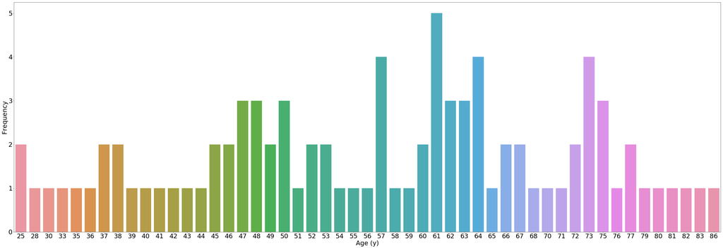

```python
# The Fig1 is a bar plot of customers' age who did purchase a healthy product
fig1 = sns.countplot(x='cust_age', data = final_data[final_data['healthy_buyer'] > 0])
fig1.figure.set_size_inches(60,20)
fig1.set_xlabel("Age (y)", fontsize=30)
fig1.set_ylabel("Frequency", fontsize=30)
fig1.tick_params(labelsize = 30)
plt.show()
```

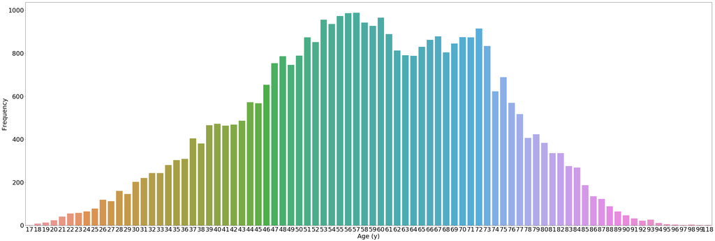

```python
# The Fig1 is a bar plot of customers' age that did not purchase a healthy product
fig1 = sns.countplot(x='cust_age', data = final_data[final_data['healthy_buyer'] < 1])
fig1.figure.set_size_inches(60,20)
fig1.set_xlabel("Age (y)", fontsize=30)
fig1.set_ylabel("Frequency", fontsize=30)
fig1.tick_params(labelsize = 30)
plt.show()
```

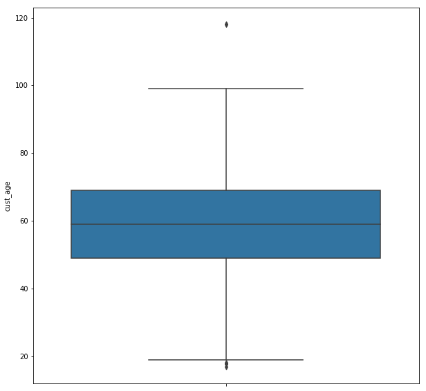

```python
# the fig2 is a boxplot to see the variation of age
fig2 = sns.boxplot(y='cust_age', data=final_data)
fig2.figure.set_size_inches(10,10)
plt.show()
```

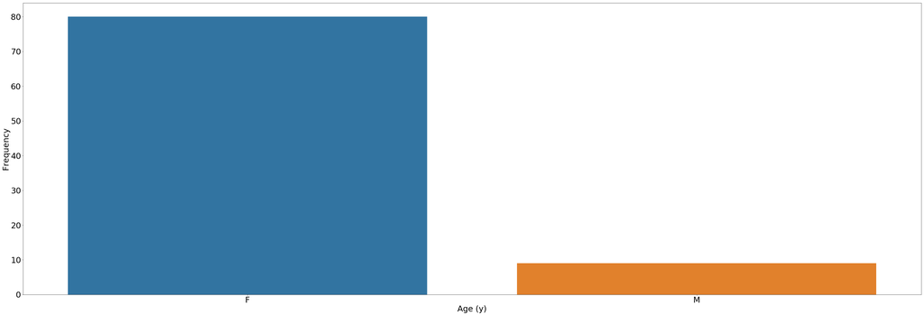

```python
# The Fig1 is a bar plot of customers who did purchase a healthy product split by gender
fig1 = sns.countplot(x='cust_gender', data = final_data[final_data['healthy_buyer'] > 0])
fig1.figure.set_size_inches(60,20)
fig1.set_xlabel("Age (y)", fontsize=30)
fig1.set_ylabel("Frequency", fontsize=30)
fig1.tick_params(labelsize = 30)
plt.show()
```

Interestingly a much higher number of women purchased a healthy product compared to men.

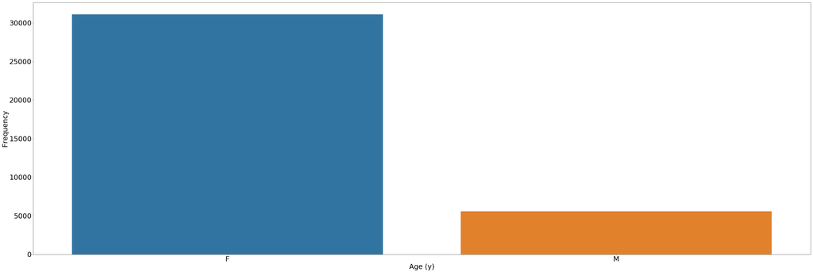

```python
# The Fig1 is a bar plot of customers who did not purchase a healthy product split by gender
fig1 = sns.countplot(x='cust_gender', data = final_data[final_data['healthy_buyer'] < 1])
fig1.figure.set_size_inches(60,20)
fig1.set_xlabel("Age (y)", fontsize=30)
fig1.set_ylabel("Frequency", fontsize=30)
fig1.tick_params(labelsize = 30)
plt.show()
```

From the bar graph above we can see that we have way more female customers who did not buy healthy products than males. This shouldn’t be too surprising as the ratio of males to females in our dataset is for every male, we have we have 6 females (rounded up).

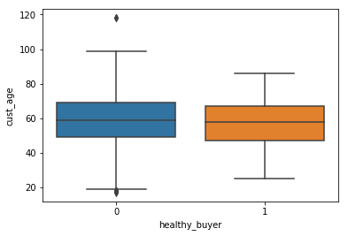

```python
# Box plot of age based on whether the customer is a healthy buyer or not
sns.boxplot(y='cust_age', x ='healthy_buyer', data = final_data)
plt.show()
```

We can see from the box plot above that the median age for a healthy buyer and a non-healthy buyer are roughly the same, but the distribution of the healthy buyers age is much smaller. Below when we restrict to only healthy buyer data and introduce gender, we see something interesting! We see that females have a larger distribution of age starting from their 20s with a median around late 50s. As for men the distribution is much smaller starting at around late 40s with a median in the mid-60s. Does this suggest that men become more conscience about healthy eating at a later age in comparison to women.

Further below is the same box plot but for non-healthy buyers and what is very interesting is the distribution and median is pretty much identical. Does this cement our suggestion that when individual decides to eat healthier a female is more likely to start at a younger age to males?

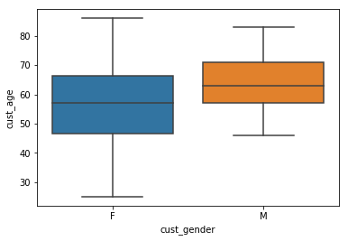

```python
# Box plot of age, gender based on the customer being a healthy buyer
sns.boxplot(y='cust_age', x ='cust_gender', data = final_data[final_data['healthy_buyer']>0])
plt.show()
```

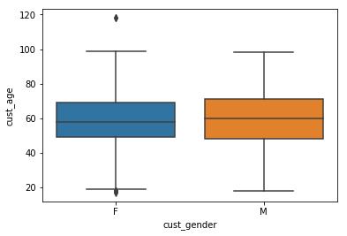

```python
# Box plot of age, gender based on the customer being a healthy buyer
sns.boxplot(y='cust_age', x ='cust_gender', data = final_data[final_data['healthy_buyer']<1])
```

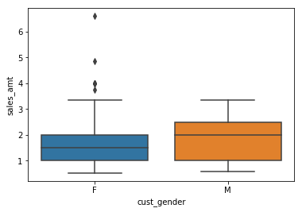

```python
# Box plot of customer gender and sales amount for healthy buyers
sns.boxplot(y='sales_amt', x ='cust_gender', data = final_data[final_data['healthy_buyer']>0])
```

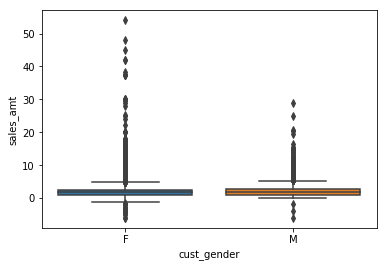

```python
# Box plot of customer gender and sales amount for non healthy buyers
sns.boxplot(y='sales_amt', x ='cust_gender', data = final_data[final_data['healthy_buyer']<1])
```

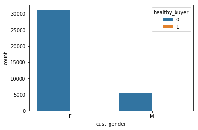

```python
# Crosstabl plot of the count of customers split by healthy buyer and gender
sns.countplot( x='cust_gender', hue= 'healthy_buyer', data= final_data)

plt.show()
```

```python
# Differences in healthy buyer between genders
pd.crosstab(final_data['cust_gender'], final_data['healthy_buyer'])
```

| healthy_buyer cust_gender | 0 | 1 |
| --- | --- | --- |
| F | 31089 | 80 |
| M | 5583 | 9 |

### Prepare the data for analysis

#### Correlation analysis

In this part we are going to evaluate how strong and significant is the correlation between variables

```python
# Creating a final dataset
final_data_two = final_data[["item_volume","sales_amt","cust_age","healthy_ind","cust_gender"]]
```

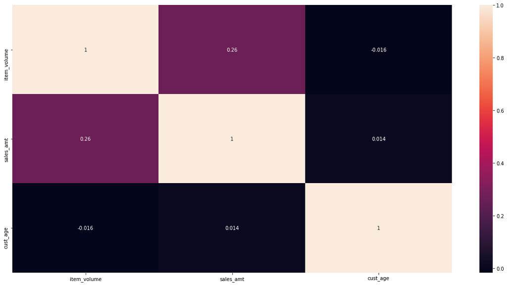

```python
# One part is checking the correlation of numerical variables to do that we can use the function`.heatmap` from `sns` library
plt.figure(figsize=(20, 10))
sns.heatmap(final_data_two.corr(),  annot=True)
```

#### Dummy variables

Sometimes to evaluate the correlartion of categorical variables it is necessary to create dummy variables. One for each level of a categorical variable.

```python
#New data set with dummy variables
cor_data = pd.get_dummies(final_data_two)
cor_data.info()
```

```
<class 'pandas.core.frame.DataFrame'>
Int64Index: 36761 entries, 0 to 37148
Data columns (total 7 columns):
item_volume        36761 non-null float64
sales_amt          36761 non-null float64
cust_age           36761 non-null int32
healthy_ind_No     36761 non-null uint8
healthy_ind_Yes    36761 non-null uint8
cust_gender_F      36761 non-null uint8
cust_gender_M      36761 non-null uint8
dtypes: float64(2), int32(1), uint8(4)
memory usage: 2.4 MB
```

#### Correlation matrix

We can calculate the correlation coefficient usinf the function .corr

```python
cor_matrix = cor_data.corr()
```

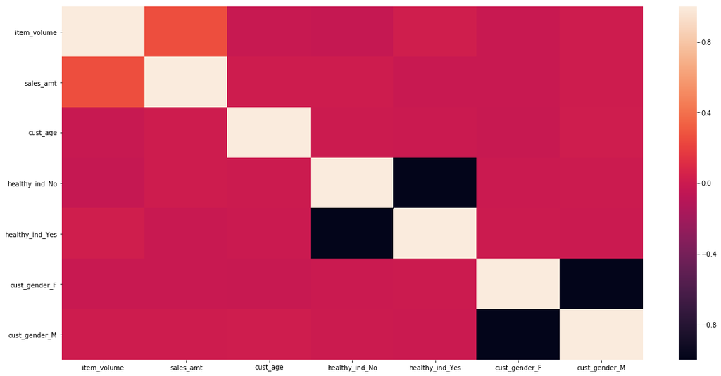

```python
plt.figure(figsize=(20, 10))
sns.heatmap(cor_matrix)
```

#### Calculating r-coefficients and p-values

```python
corr_type, corr_matrix, corr_ps = rp.corr_case(cor_data)
```

The function .corr_case generates three matrixes, one about the type of correlation, the second matrix shows the r coefficient and the last matrix shows the p-value of the correlation

```python
corr_ps
```

|  | item_volume | sales_amt | cust_age | healthy_ind_No | healthy_ind_Yes | cust_gender_F | cust_gender_M |
| --- | --- | --- | --- | --- | --- | --- | --- |
| item_volume | 0.0000 | 0.0000 | 0.0022 | 0.0000 | 0.0000 | 0.0160 | 0.0160 |
| sales_amt | 0.0000 | 0.0000 | 0.0088 | 0.0256 | 0.0256 | 0.0202 | 0.0202 |
| cust_age | 0.0022 | 0.0088 | 0.0000 | 0.3605 | 0.3605 | 0.0000 | 0.0000 |
| healthy_ind_No | 0.0000 | 0.0256 | 0.3605 | 0.0000 | 0.0000 | 0.1799 | 0.1799 |
| healthy_ind_Yes | 0.0000 | 0.0256 | 0.3605 | 0.0000 | 0.0000 | 0.1799 | 0.1799 |
| cust_gender_F | 0.0160 | 0.0202 | 0.0000 | 0.1799 | 0.1799 | 0.0000 | 0.0000 |
| cust_gender_M | 0.0160 | 0.0202 | 0.0000 | 0.1799 | 0.1799 | 0.0000 | 0.0000 |

The function .corr_pair generates one matrix, where it shows for each pair of variables the r coefficient and the p-value of the correlation

With that outcome it is possible to check how many correlations are very high (r coefficient higher than 0.5 or lower than -0.5) and significant (p-value lower than 0.05)

```python
corr_table = rp.corr_pair(cor_data)
```

```python
corr_table
```

|  | r value | p-value | N |
| --- | --- | --- | --- |
| item_volume & sales_amt | 0.2648 | 0.0000 | 36761 |
| item_volume & cust_age | -0.0160 | 0.0022 | 36761 |
| item_volume & healthy_ind_No | -0.0296 | 0.0000 | 36761 |
| item_volume & healthy_ind_Yes | 0.0296 | 0.0000 | 36761 |
| item_volume & cust_gender_F | -0.0126 | 0.0160 | 36761 |
| item_volume & cust_gender_M | 0.0126 | 0.0160 | 36761 |
| sales_amt & cust_age | 0.0137 | 0.0088 | 36761 |
| sales_amt & healthy_ind_No | 0.0116 | 0.0256 | 36761 |
| sales_amt & healthy_ind_Yes | -0.0116 | 0.0256 | 36761 |
| sales_amt & cust_gender_F | -0.0121 | 0.0202 | 36761 |
| sales_amt & cust_gender_M | 0.0121 | 0.0202 | 36761 |
| cust_age & healthy_ind_No | 0.0048 | 0.3605 | 36761 |
| cust_age & healthy_ind_Yes | -0.0048 | 0.3605 | 36761 |
| cust_age & cust_gender_F | -0.0232 | 0.0000 | 36761 |
| cust_age & cust_gender_M | 0.0232 | 0.0000 | 36761 |
| healthy_ind_No & healthy_ind_Yes | -1.0000 | 0.0000 | 36761 |
| healthy_ind_No & cust_gender_F | -0.0070 | 0.1799 | 36761 |
| healthy_ind_No & cust_gender_M | 0.0070 | 0.1799 | 36761 |
| healthy_ind_Yes & cust_gender_F | 0.0070 | 0.1799 | 36761 |
| healthy_ind_Yes & cust_gender_M | -0.0070 | 0.1799 | 36761 |
| cust_gender_F & cust_gender_M | -1.0000 | 0.0000 | 36761 |

```python
# The r value and p-value are not numeric values
corr_table.info()
```

```
<class 'pandas.core.frame.DataFrame'>
Index: 21 entries, item_volume & sales_amt to cust_gender_F & cust_gender_M
Data columns (total 3 columns):
r value    21 non-null object
p-value    21 non-null object
N          21 non-null int64
dtypes: int64(1), object(2)
memory usage: 1.3+ KB
```

```python
# Usiong pd.to_numeric we can solve the problem
corr_table['p-value']= pd.to_numeric(corr_table['p-value'])
corr_table['r value']= pd.to_numeric(corr_table['r value'])
```

```python
corr_table.info()
```

```
<class 'pandas.core.frame.DataFrame'>
Index: 21 entries, item_volume & sales_amt to cust_gender_F & cust_gender_M
Data columns (total 3 columns):
r value    21 non-null float64
p-value    21 non-null float64
N          21 non-null int64
dtypes: float64(2), int64(1)
memory usage: 1.3+ KB
```

```python
corr_table
```

|  | r value | p-value | N |
| --- | --- | --- | --- |
| item_volume & sales_amt | 0.2648 | 0.0000 | 36761 |
| item_volume & cust_age | -0.0160 | 0.0022 | 36761 |
| item_volume & healthy_ind_No | -0.0296 | 0.0000 | 36761 |
| item_volume & healthy_ind_Yes | 0.0296 | 0.0000 | 36761 |
| item_volume & cust_gender_F | -0.0126 | 0.0160 | 36761 |
| item_volume & cust_gender_M | 0.0126 | 0.0160 | 36761 |
| sales_amt & cust_age | 0.0137 | 0.0088 | 36761 |
| sales_amt & healthy_ind_No | 0.0116 | 0.0256 | 36761 |
| sales_amt & healthy_ind_Yes | -0.0116 | 0.0256 | 36761 |
| sales_amt & cust_gender_F | -0.0121 | 0.0202 | 36761 |
| sales_amt & cust_gender_M | 0.0121 | 0.0202 | 36761 |
| cust_age & healthy_ind_No | 0.0048 | 0.3605 | 36761 |
| cust_age & healthy_ind_Yes | -0.0048 | 0.3605 | 36761 |
| cust_age & cust_gender_F | -0.0232 | 0.0000 | 36761 |
| cust_age & cust_gender_M | 0.0232 | 0.0000 | 36761 |
| healthy_ind_No & healthy_ind_Yes | -1.0000 | 0.0000 | 36761 |
| healthy_ind_No & cust_gender_F | -0.0070 | 0.1799 | 36761 |
| healthy_ind_No & cust_gender_M | 0.0070 | 0.1799 | 36761 |
| healthy_ind_Yes & cust_gender_F | 0.0070 | 0.1799 | 36761 |
| healthy_ind_Yes & cust_gender_M | -0.0070 | 0.1799 | 36761 |
| cust_gender_F & cust_gender_M | -1.0000 | 0.0000 | 36761 |

```python
corr_table[(corr_table['r value'] > 0.5)]
```

|  | r value | p-value | N |
| --- | --- | --- | --- |

As we can see no significant results greater than 0.5.

```python
corr_table[(corr_table['r value']  < -0.5)]
```

|  | r value | p-value | N |
| --- | --- | --- | --- |
| healthy_ind_No & healthy_ind_Yes | -1.0 | 0.0 | 36761 |
| cust_gender_F & cust_gender_M | -1.0 | 0.0 | 36761 |

Two negatively correlated outputs when we look at smaller than 0.5. This makes sense as the first outcome combinations are the unique values of their corresponding columns and given the unique count of the columns are two that means either one or the other value is ever present.

### Preparing the data

#### Spliting the data

```python
# Feature selection
feature_cols = ['item_volume', 'sales_amt', 'cust_age', 'cust_gender_F',
       'cust_gender_M']
X = cor_data[feature_cols]
y = final_data.healthy_ind
X_train, X_test, y_train, y_test=train_test_split(X, y,
                                                  test_size = 0.25,
                                                  random_state = 123)
```

#### Set up the model and train the model

In this step we are going to set up the model with 500 trees, using entropy as the parameter to find the optimal tree and with a maximum depth of 5 nodes. Then we are going to train the model using the function .fit

```python
clf = RandomForestClassifier(n_estimators=500,criterion = 'entropy', max_depth=5,random_state=123)
clf.fit(X_train,y_train)
```

```
RandomForestClassifier(bootstrap=True, class_weight=None, criterion='entropy',
            max_depth=5, max_features='auto', max_leaf_nodes=None,
            min_impurity_decrease=0.0, min_impurity_split=None,
            min_samples_leaf=1, min_samples_split=2,
            min_weight_fraction_leaf=0.0, n_estimators=500, n_jobs=None,
            oob_score=False, random_state=123, verbose=0, warm_start=False)
```

```python
# Classify the test subset using .predict()
y_pred = clf.predict(X_test)
```

```python
# Calculate the accuracy using metrics.accuracy_score(y_test,y_pred)
print("Accuracy:", metrics.accuracy_score(y_test,y_pred))
```

```
Accuracy: 0.9974975519529975
```

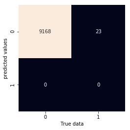

```python
# y_test is a dataframe and to use the function confusion_matrix it is necessary to convert y_test to a list
from sklearn.metrics import confusion_matrix
y_true = y_test.tolist()
mat = confusion_matrix(y_true,y_pred)
sns.heatmap(mat.T, square =True, annot = True, fmt = 'd', cbar= False)
plt.xlabel('True data')
plt.ylabel('predicted values')
```

From the confusion matrix above we can see that for 0 a count of 9168 true positives and 0 false positive predictions which means no customer who did not purchase a healthy product was labelled as a healthy buyer. We can also see for 1 a count of 0 true positive and 23 false negatives, which means all customers who bought a healthy product were labelled as non-healthy buyers. The reason is for the sheer volume of non healthy buyers in compariosn to healthy buyers. In this case our calssifier classified all our robservations as non healthy buyers due to 100% recognition rate (sensitivity) for non healthy buyers class and a 0% for healthy buyer class.

Let's check which variables are the most important to classify the dataset

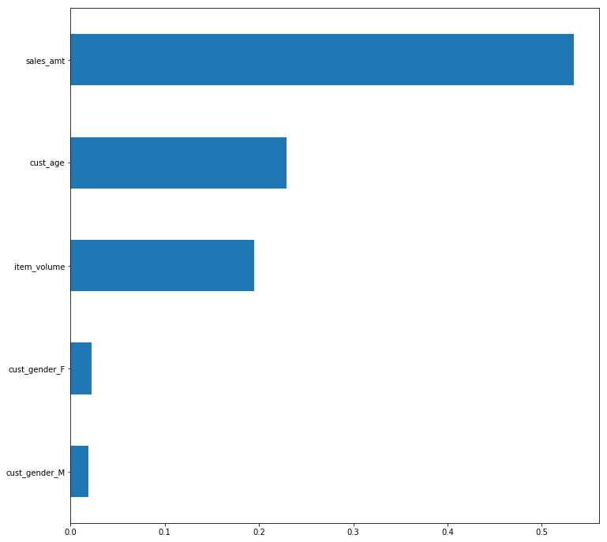

```python
feature_importances = pd.Series(clf.feature_importances_, index = X.columns)
feature_importances = feature_importances.sort_values()
feature_importances.plot(kind='barh', figsize = (12,12))
```

From the graph plot above we can see that gender has the least importance in classifying but was still somewhat important.

You can also visualise the individual trees, each tree represents a subset of the model. In this particular case we are interested in a single tree, the tree numer 90 but you can explore from the tree 0 to the the tree 499!

```python
from sklearn.externals.six import StringIO
from IPython.display import Image
from sklearn.tree import export_graphviz
import pydotplus
```

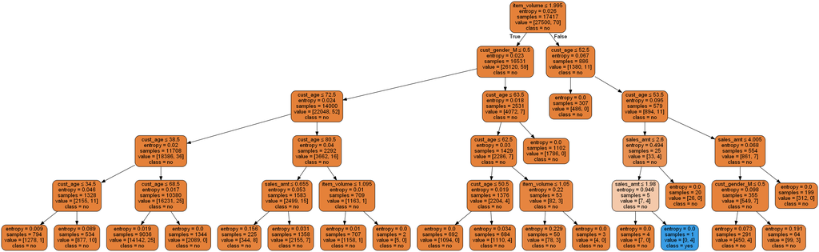

```python
dot_data = StringIO()
estimator = clf.estimators_[90]
export_graphviz(estimator, out_file=dot_data,
                filled=True, rounded=True,
                special_characters=True, feature_names=X_train.columns,class_names = ['no', 'yes'])
graph = pydotplus.graph_from_dot_data(dot_data.getvalue())
Image(graph.create_png())
```

After creating our model, we can conclude that it was potentially overfitted as it had a very high accuracy rate of 99.7%. We could not find any variables with a significant correlation with the healthy indicator either. The model was able to predict every observation correctly for customers who did not buy a healthy product but was unable to predict one single observation correct for a customer who did purchase a healthy product. We do understand that is due to unproportioned dataset which was heavily weighted towards customers who did not buy a healthy product.

This means my concerns outlined in the source the data section seems to have been cemented as the out of date data for the healthy products means a lot of products currently healthy are not in the list.

This means we must reject the null hypothesis that the model is significantly able to classify a customer as an individual who is likely to purchase a healthy product. As a result, we must then accept our alternative hypothesis which is the model is significantly unable to classify a customer as an individual who is likely to purchase a healthy product.

I believe if all the concerns outlined in the source the data are addressed and possibly selecting better variables it could be possible to create a function model that will be able to significantly determine if a customer will purchase a healthy product.